# Risk Factor Analysis

## Outcome Variable

**Outcome Variable:** whz

## Predictor Variables

**Intervention Variable:** mwtkg

**Adjustment Set:**

- arm
- W_mage
- W_fage
- meducyrs
- feducyrs
- single
- brthmon
- W_gagebrth
- W_birthwt
- W_birthlen
- vagbrth
- delta_W_mage
- delta_W_fage
- delta_meducyrs
- delta_feducyrs
- delta_single
- delta_brthmon
- delta_W_gagebrth
- delta_W_birthwt
- delta_W_birthlen
- delta_vagbrth

## Stratifying Variables

The analysis was stratified on these variable(s):

- agecat
- studyid
- country

## Data Summary

| agecat | studyid | country | mwtkg | n_cell | n |
| --- | --- | --- | --- | --- | --- |
| 6 months | ki0047075b-MAL-ED | BANGLADESH | >=58 kg | 46 | 241 |
| 6 months | ki0047075b-MAL-ED | BANGLADESH | <52 kg | 154 | 241 |
| 6 months | ki0047075b-MAL-ED | BANGLADESH | [52-58) kg | 41 | 241 |
| 6 months | ki0047075b-MAL-ED | BRAZIL | >=58 kg | 137 | 208 |
| 6 months | ki0047075b-MAL-ED | BRAZIL | <52 kg | 37 | 208 |
| 6 months | ki0047075b-MAL-ED | BRAZIL | [52-58) kg | 34 | 208 |
| 6 months | ki0047075b-MAL-ED | INDIA | >=58 kg | 40 | 235 |
| 6 months | ki0047075b-MAL-ED | INDIA | <52 kg | 146 | 235 |
| 6 months | ki0047075b-MAL-ED | INDIA | [52-58) kg | 49 | 235 |
| 6 months | ki0047075b-MAL-ED | NEPAL | >=58 kg | 79 | 236 |
| 6 months | ki0047075b-MAL-ED | NEPAL | <52 kg | 75 | 236 |
| 6 months | ki0047075b-MAL-ED | NEPAL | [52-58) kg | 82 | 236 |
| 6 months | ki0047075b-MAL-ED | PERU | >=58 kg | 100 | 272 |
| 6 months | ki0047075b-MAL-ED | PERU | <52 kg | 107 | 272 |
| 6 months | ki0047075b-MAL-ED | PERU | [52-58) kg | 65 | 272 |
| 6 months | ki0047075b-MAL-ED | SOUTH AFRICA | >=58 kg | 179 | 249 |
| 6 months | ki0047075b-MAL-ED | SOUTH AFRICA | <52 kg | 29 | 249 |
| 6 months | ki0047075b-MAL-ED | SOUTH AFRICA | [52-58) kg | 41 | 249 |
| 6 months | ki0047075b-MAL-ED | TANZANIA, UNITED REPUBLIC OF | >=58 kg | 94 | 247 |
| 6 months | ki0047075b-MAL-ED | TANZANIA, UNITED REPUBLIC OF | <52 kg | 95 | 247 |
| 6 months | ki0047075b-MAL-ED | TANZANIA, UNITED REPUBLIC OF | [52-58) kg | 58 | 247 |
| 6 months | ki1000304b-SAS-CompFeed | INDIA | >=58 kg | 99 | 1328 |
| 6 months | ki1000304b-SAS-CompFeed | INDIA | <52 kg | 1016 | 1328 |
| 6 months | ki1000304b-SAS-CompFeed | INDIA | [52-58) kg | 213 | 1328 |
| 6 months | ki1017093-NIH-Birth | BANGLADESH | >=58 kg | 71 | 536 |
| 6 months | ki1017093-NIH-Birth | BANGLADESH | <52 kg | 384 | 536 |
| 6 months | ki1017093-NIH-Birth | BANGLADESH | [52-58) kg | 81 | 536 |
| 6 months | ki1017093b-PROVIDE | BANGLADESH | >=58 kg | 106 | 581 |
| 6 months | ki1017093b-PROVIDE | BANGLADESH | <52 kg | 369 | 581 |
| 6 months | ki1017093b-PROVIDE | BANGLADESH | [52-58) kg | 106 | 581 |

[output cut: 57 more lines]

The following strata were considered:

- agecat: 24 months, studyid: ki0047075b-MAL-ED, country: BANGLADESH
- agecat: 24 months, studyid: ki0047075b-MAL-ED, country: BRAZIL
- agecat: 24 months, studyid: ki0047075b-MAL-ED, country: INDIA
- agecat: 24 months, studyid: ki0047075b-MAL-ED, country: NEPAL
- agecat: 24 months, studyid: ki0047075b-MAL-ED, country: PERU
- agecat: 24 months, studyid: ki0047075b-MAL-ED, country: SOUTH AFRICA
- agecat: 24 months, studyid: ki0047075b-MAL-ED, country: TANZANIA, UNITED REPUBLIC OF
- agecat: 24 months, studyid: ki1017093-NIH-Birth, country: BANGLADESH
- agecat: 24 months, studyid: ki1017093b-PROVIDE, country: BANGLADESH
- agecat: 24 months, studyid: ki1017093c-NIH-Crypto, country: BANGLADESH
- agecat: 24 months, studyid: ki1066203-TanzaniaChild2, country: TANZANIA, UNITED REPUBLIC OF
- agecat: 24 months, studyid: ki1119695-PROBIT, country: BELARUS
- agecat: 24 months, studyid: ki1126311-ZVITAMBO, country: ZIMBABWE
- agecat: 24 months, studyid: ki1148112-LCNI-5, country: MALAWI
- agecat: 6 months, studyid: ki0047075b-MAL-ED, country: BANGLADESH
- agecat: 6 months, studyid: ki0047075b-MAL-ED, country: BRAZIL
- agecat: 6 months, studyid: ki0047075b-MAL-ED, country: INDIA
- agecat: 6 months, studyid: ki0047075b-MAL-ED, country: NEPAL
- agecat: 6 months, studyid: ki0047075b-MAL-ED, country: PERU
- agecat: 6 months, studyid: ki0047075b-MAL-ED, country: SOUTH AFRICA
- agecat: 6 months, studyid: ki0047075b-MAL-ED, country: TANZANIA, UNITED REPUBLIC OF
- agecat: 6 months, studyid: ki1000304b-SAS-CompFeed, country: INDIA
- agecat: 6 months, studyid: ki1017093-NIH-Birth, country: BANGLADESH
- agecat: 6 months, studyid: ki1017093b-PROVIDE, country: BANGLADESH
- agecat: 6 months, studyid: ki1017093c-NIH-Crypto, country: BANGLADESH
- agecat: 6 months, studyid: ki1066203-TanzaniaChild2, country: TANZANIA, UNITED REPUBLIC OF
- agecat: 6 months, studyid: ki1119695-PROBIT, country: BELARUS
- agecat: 6 months, studyid: ki1126311-ZVITAMBO, country: ZIMBABWE
- agecat: 6 months, studyid: ki1148112-LCNI-5, country: MALAWI

### Dropped Strata

Some strata were dropped due to rare outcomes:

- agecat: 24 months, studyid: ki1066203-TanzaniaChild2, country: TANZANIA, UNITED REPUBLIC OF

## Methods Detail

We’re interested in the causal parameters $E[Y_a]$ for all values of $a \in \mathcal{A}$. These parameters represent the mean outcome if, possibly contrary to fact, we intervened to set all units to have $A=a$. Under the randomization and positivity assumptions, these are identified by the statistical parameters $\psi_a=E_W[E_{Y|A,W}(Y|A=a,W)]$. In addition, we’re interested in the mean of $Y$, $E[Y]$ under no intervention (the observed mean). We will estimate these parameters by using SuperLearner to fit the relevant likelihood factors – $E_{Y|A,W}(Y|A=a,W)$ and $p(A=a|W)$, and then updating our likelihood fit using a joint TMLE.

For unadjusted analyses ($W=\{\}$), initial likelihoods were estimated using Lrnr_glm to estimate the simple $E(Y|A)$ and Lrnr_mean to estimate $p(A)$. For adjusted analyses, a small library containing Lrnr_glmnet, Lrnr_xgboost, and Lrnr_mean was used.

Having estimated these parameters, we will then use the delta method to estimate relative risks and attributable risks relative to a prespecified baseline level of $A$.

# Results Detail

## Results Plots

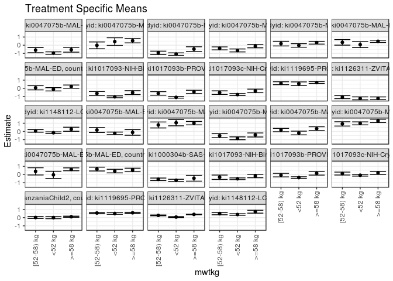

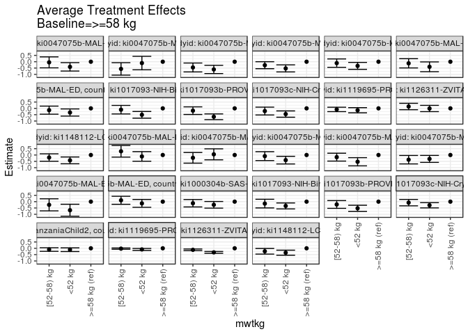

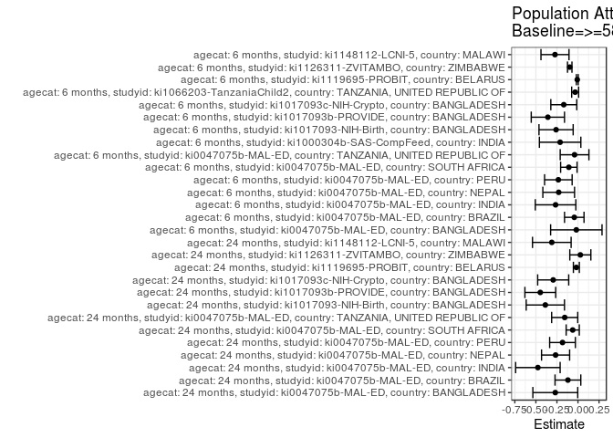

## Results Table

### Parameter: TSM

| agecat | studyid | country | intervention_level | baseline_level | estimate | ci_lower | ci_upper |
| --- | --- | --- | --- | --- | --- | --- | --- |
| 6 months | ki0047075b-MAL-ED | BANGLADESH | >=58 kg | NA | -0.1201200 | -0.4648776 | 0.2246375 |
| 6 months | ki0047075b-MAL-ED | BANGLADESH | <52 kg | NA | -0.2328840 | -0.3864994 | -0.0792685 |
| 6 months | ki0047075b-MAL-ED | BANGLADESH | [52-58) kg | NA | 0.1728621 | -0.1288497 | 0.4745739 |
| 6 months | ki0047075b-MAL-ED | BRAZIL | >=58 kg | NA | 1.0084826 | 0.7996933 | 1.2172719 |
| 6 months | ki0047075b-MAL-ED | BRAZIL | <52 kg | NA | 1.0626835 | 0.6837072 | 1.4416598 |
| 6 months | ki0047075b-MAL-ED | BRAZIL | [52-58) kg | NA | 0.7869662 | 0.4209524 | 1.1529799 |
| 6 months | ki0047075b-MAL-ED | INDIA | >=58 kg | NA | -0.4327205 | -0.6782692 | -0.1871718 |
| 6 months | ki0047075b-MAL-ED | INDIA | <52 kg | NA | -0.8380747 | -1.0125964 | -0.6635531 |
| 6 months | ki0047075b-MAL-ED | INDIA | [52-58) kg | NA | -0.5215314 | -0.7695546 | -0.2735082 |
| 6 months | ki0047075b-MAL-ED | NEPAL | >=58 kg | NA | 0.3400036 | 0.1083353 | 0.5716718 |
| 6 months | ki0047075b-MAL-ED | NEPAL | <52 kg | NA | -0.1936420 | -0.4199105 | 0.0326264 |
| 6 months | ki0047075b-MAL-ED | NEPAL | [52-58) kg | NA | 0.1704571 | -0.0368133 | 0.3777275 |
| 6 months | ki0047075b-MAL-ED | PERU | >=58 kg | NA | 1.2894594 | 1.0855957 | 1.4933230 |
| 6 months | ki0047075b-MAL-ED | PERU | <52 kg | NA | 0.9816149 | 0.7984070 | 1.1648228 |
| 6 months | ki0047075b-MAL-ED | PERU | [52-58) kg | NA | 0.9183196 | 0.6556577 | 1.1809814 |
| 6 months | ki0047075b-MAL-ED | SOUTH AFRICA | >=58 kg | NA | 0.6374906 | 0.4602427 | 0.8147385 |
| 6 months | ki0047075b-MAL-ED | SOUTH AFRICA | <52 kg | NA | -0.0402500 | -0.4768422 | 0.3963422 |
| 6 months | ki0047075b-MAL-ED | SOUTH AFRICA | [52-58) kg | NA | 0.3864744 | -0.0550914 | 0.8280401 |
| 6 months | ki0047075b-MAL-ED | TANZANIA, UNITED REPUBLIC OF | >=58 kg | NA | 0.5576616 | 0.3426185 | 0.7727047 |
| 6 months | ki0047075b-MAL-ED | TANZANIA, UNITED REPUBLIC OF | <52 kg | NA | 0.4209114 | 0.2002764 | 0.6415464 |
| 6 months | ki0047075b-MAL-ED | TANZANIA, UNITED REPUBLIC OF | [52-58) kg | NA | 0.6649261 | 0.4329443 | 0.8969080 |
| 6 months | ki1000304b-SAS-CompFeed | INDIA | >=58 kg | NA | -0.4554415 | -0.8076249 | -0.1032581 |
| 6 months | ki1000304b-SAS-CompFeed | INDIA | <52 kg | NA | -0.7051776 | -0.8330346 | -0.5773205 |
| 6 months | ki1000304b-SAS-CompFeed | INDIA | [52-58) kg | NA | -0.5811114 | -0.7337729 | -0.4284500 |
| 6 months | ki1017093-NIH-Birth | BANGLADESH | >=58 kg | NA | -0.1788139 | -0.3892730 | 0.0316452 |
| 6 months | ki1017093-NIH-Birth | BANGLADESH | <52 kg | NA | -0.5164836 | -0.6212174 | -0.4117498 |
| 6 months | ki1017093-NIH-Birth | BANGLADESH | [52-58) kg | NA | -0.3321153 | -0.6005253 | -0.0637053 |
| 6 months | ki1017093b-PROVIDE | BANGLADESH | >=58 kg | NA | 0.1495575 | -0.0698309 | 0.3689459 |
| 6 months | ki1017093b-PROVIDE | BANGLADESH | <52 kg | NA | -0.3744182 | -0.4750969 | -0.2737394 |
| 6 months | ki1017093b-PROVIDE | BANGLADESH | [52-58) kg | NA | -0.0725695 | -0.2893279 | 0.1441888 |

[output cut: 54 more lines]

### Parameter: E(Y)

| agecat | studyid | country | intervention_level | baseline_level | estimate | ci_lower | ci_upper |
| --- | --- | --- | --- | --- | --- | --- | --- |
| 6 months | ki0047075b-MAL-ED | BANGLADESH | NA | NA | -0.1397960 | -0.2688682 | -0.0107238 |
| 6 months | ki0047075b-MAL-ED | BRAZIL | NA | NA | 0.9644952 | 0.7999744 | 1.1290160 |
| 6 months | ki0047075b-MAL-ED | INDIA | NA | NA | -0.6987943 | -0.8241325 | -0.5734561 |
| 6 months | ki0047075b-MAL-ED | NEPAL | NA | NA | 0.1110452 | -0.0202712 | 0.2423616 |
| 6 months | ki0047075b-MAL-ED | PERU | NA | NA | 1.0563787 | 0.9342938 | 1.1784635 |
| 6 months | ki0047075b-MAL-ED | SOUTH AFRICA | NA | NA | 0.5290428 | 0.3750394 | 0.6830463 |
| 6 months | ki0047075b-MAL-ED | TANZANIA, UNITED REPUBLIC OF | NA | NA | 0.5170513 | 0.3872178 | 0.6468847 |
| 6 months | ki1000304b-SAS-CompFeed | INDIA | NA | NA | -0.6674586 | -0.8042294 | -0.5306877 |
| 6 months | ki1017093-NIH-Birth | BANGLADESH | NA | NA | -0.4389101 | -0.5279432 | -0.3498771 |
| 6 months | ki1017093b-PROVIDE | BANGLADESH | NA | NA | -0.2079891 | -0.2925599 | -0.1234183 |
| 6 months | ki1017093c-NIH-Crypto | BANGLADESH | NA | NA | 0.0297622 | -0.0491685 | 0.1086930 |
| 6 months | ki1066203-TanzaniaChild2 | TANZANIA, UNITED REPUBLIC OF | NA | NA | 0.0780261 | 0.0247830 | 0.1312691 |
| 6 months | ki1119695-PROBIT | BELARUS | NA | NA | 0.5834072 | 0.5254491 | 0.6413653 |
| 6 months | ki1126311-ZVITAMBO | ZIMBABWE | NA | NA | 0.2953392 | 0.2687669 | 0.3219114 |
| 6 months | ki1148112-LCNI-5 | MALAWI | NA | NA | 0.4518399 | 0.3806212 | 0.5230586 |
| 24 months | ki0047075b-MAL-ED | BANGLADESH | NA | NA | -0.8208255 | -0.9429246 | -0.6987264 |
| 24 months | ki0047075b-MAL-ED | BRAZIL | NA | NA | 0.4282738 | 0.2252365 | 0.6313111 |
| 24 months | ki0047075b-MAL-ED | INDIA | NA | NA | -0.9525664 | -1.0684455 | -0.8366872 |
| 24 months | ki0047075b-MAL-ED | NEPAL | NA | NA | -0.3764474 | -0.4898516 | -0.2630431 |
| 24 months | ki0047075b-MAL-ED | PERU | NA | NA | 0.1199005 | -0.0000331 | 0.2398341 |
| 24 months | ki0047075b-MAL-ED | SOUTH AFRICA | NA | NA | 0.4096154 | 0.2902946 | 0.5289362 |
| 24 months | ki0047075b-MAL-ED | TANZANIA, UNITED REPUBLIC OF | NA | NA | 0.0500935 | -0.0748234 | 0.1750103 |
| 24 months | ki1017093-NIH-Birth | BANGLADESH | NA | NA | -0.9115790 | -1.0095022 | -0.8136559 |
| 24 months | ki1017093b-PROVIDE | BANGLADESH | NA | NA | -0.8864991 | -0.9695215 | -0.8034768 |
| 24 months | ki1017093c-NIH-Crypto | BANGLADESH | NA | NA | -0.6103502 | -0.7050157 | -0.5156847 |
| 24 months | ki1119695-PROBIT | BELARUS | NA | NA | 0.6877387 | 0.5737746 | 0.8017027 |
| 24 months | ki1126311-ZVITAMBO | ZIMBABWE | NA | NA | -1.1865133 | -1.2873598 | -1.0856668 |
| 24 months | ki1148112-LCNI-5 | MALAWI | NA | NA | -0.0467082 | -0.1287046 | 0.0352882 |

### Parameter: ATE

| agecat | studyid | country | intervention_level | baseline_level | estimate | ci_lower | ci_upper |
| --- | --- | --- | --- | --- | --- | --- | --- |
| 6 months | ki0047075b-MAL-ED | BANGLADESH | >=58 kg | >=58 kg | 0.0000000 | 0.0000000 | 0.0000000 |
| 6 months | ki0047075b-MAL-ED | BANGLADESH | <52 kg | >=58 kg | -0.1127639 | -0.4906237 | 0.2650958 |
| 6 months | ki0047075b-MAL-ED | BANGLADESH | [52-58) kg | >=58 kg | 0.2929821 | -0.1652009 | 0.7511652 |
| 6 months | ki0047075b-MAL-ED | BRAZIL | >=58 kg | >=58 kg | 0.0000000 | 0.0000000 | 0.0000000 |
| 6 months | ki0047075b-MAL-ED | BRAZIL | <52 kg | >=58 kg | 0.0542009 | -0.3791942 | 0.4875961 |
| 6 months | ki0047075b-MAL-ED | BRAZIL | [52-58) kg | >=58 kg | -0.2215164 | -0.6431652 | 0.2001324 |
| 6 months | ki0047075b-MAL-ED | INDIA | >=58 kg | >=58 kg | 0.0000000 | 0.0000000 | 0.0000000 |
| 6 months | ki0047075b-MAL-ED | INDIA | <52 kg | >=58 kg | -0.4053542 | -0.7065565 | -0.1041520 |
| 6 months | ki0047075b-MAL-ED | INDIA | [52-58) kg | >=58 kg | -0.0888109 | -0.4390024 | 0.2613806 |
| 6 months | ki0047075b-MAL-ED | NEPAL | >=58 kg | >=58 kg | 0.0000000 | 0.0000000 | 0.0000000 |
| 6 months | ki0047075b-MAL-ED | NEPAL | <52 kg | >=58 kg | -0.5336456 | -0.8575672 | -0.2097240 |
| 6 months | ki0047075b-MAL-ED | NEPAL | [52-58) kg | >=58 kg | -0.1695465 | -0.4802575 | 0.1411645 |
| 6 months | ki0047075b-MAL-ED | PERU | >=58 kg | >=58 kg | 0.0000000 | 0.0000000 | 0.0000000 |
| 6 months | ki0047075b-MAL-ED | PERU | <52 kg | >=58 kg | -0.3078445 | -0.5828904 | -0.0327986 |
| 6 months | ki0047075b-MAL-ED | PERU | [52-58) kg | >=58 kg | -0.3711398 | -0.7044904 | -0.0377892 |
| 6 months | ki0047075b-MAL-ED | SOUTH AFRICA | >=58 kg | >=58 kg | 0.0000000 | 0.0000000 | 0.0000000 |
| 6 months | ki0047075b-MAL-ED | SOUTH AFRICA | <52 kg | >=58 kg | -0.6777406 | -1.1495511 | -0.2059301 |
| 6 months | ki0047075b-MAL-ED | SOUTH AFRICA | [52-58) kg | >=58 kg | -0.2510162 | -0.7272991 | 0.2252667 |
| 6 months | ki0047075b-MAL-ED | TANZANIA, UNITED REPUBLIC OF | >=58 kg | >=58 kg | 0.0000000 | 0.0000000 | 0.0000000 |
| 6 months | ki0047075b-MAL-ED | TANZANIA, UNITED REPUBLIC OF | <52 kg | >=58 kg | -0.1367502 | -0.4451171 | 0.1716167 |
| 6 months | ki0047075b-MAL-ED | TANZANIA, UNITED REPUBLIC OF | [52-58) kg | >=58 kg | 0.1072646 | -0.2096436 | 0.4241727 |
| 6 months | ki1000304b-SAS-CompFeed | INDIA | >=58 kg | >=58 kg | 0.0000000 | 0.0000000 | 0.0000000 |
| 6 months | ki1000304b-SAS-CompFeed | INDIA | <52 kg | >=58 kg | -0.2497360 | -0.5110818 | 0.0116097 |
| 6 months | ki1000304b-SAS-CompFeed | INDIA | [52-58) kg | >=58 kg | -0.1256699 | -0.4183825 | 0.1670427 |
| 6 months | ki1017093-NIH-Birth | BANGLADESH | >=58 kg | >=58 kg | 0.0000000 | 0.0000000 | 0.0000000 |
| 6 months | ki1017093-NIH-Birth | BANGLADESH | <52 kg | >=58 kg | -0.3376697 | -0.5729011 | -0.1024383 |
| 6 months | ki1017093-NIH-Birth | BANGLADESH | [52-58) kg | >=58 kg | -0.1533014 | -0.4950425 | 0.1884396 |
| 6 months | ki1017093b-PROVIDE | BANGLADESH | >=58 kg | >=58 kg | 0.0000000 | 0.0000000 | 0.0000000 |
| 6 months | ki1017093b-PROVIDE | BANGLADESH | <52 kg | >=58 kg | -0.5239757 | -0.7657595 | -0.2821918 |
| 6 months | ki1017093b-PROVIDE | BANGLADESH | [52-58) kg | >=58 kg | -0.2221270 | -0.5305899 | 0.0863358 |

[output cut: 54 more lines]

### Parameter: PAR

| agecat | studyid | country | intervention_level | baseline_level | estimate | ci_lower | ci_upper |
| --- | --- | --- | --- | --- | --- | --- | --- |
| 6 months | ki0047075b-MAL-ED | BANGLADESH | >=58 kg | NA | -0.0196760 | -0.3248016 | 0.2854497 |
| 6 months | ki0047075b-MAL-ED | BRAZIL | >=58 kg | NA | -0.0439874 | -0.1597152 | 0.0717405 |
| 6 months | ki0047075b-MAL-ED | INDIA | >=58 kg | NA | -0.2660738 | -0.5068169 | -0.0253307 |
| 6 months | ki0047075b-MAL-ED | NEPAL | >=58 kg | NA | -0.2289584 | -0.4171894 | -0.0407274 |
| 6 months | ki0047075b-MAL-ED | PERU | >=58 kg | NA | -0.2330807 | -0.3967636 | -0.0693978 |
| 6 months | ki0047075b-MAL-ED | SOUTH AFRICA | >=58 kg | NA | -0.1084477 | -0.2060491 | -0.0108463 |
| 6 months | ki0047075b-MAL-ED | TANZANIA, UNITED REPUBLIC OF | >=58 kg | NA | -0.0406103 | -0.2111227 | 0.1299021 |
| 6 months | ki1000304b-SAS-CompFeed | INDIA | >=58 kg | NA | -0.2120171 | -0.4581262 | 0.0340921 |
| 6 months | ki1017093-NIH-Birth | BANGLADESH | >=58 kg | NA | -0.2600963 | -0.4630045 | -0.0571880 |
| 6 months | ki1017093b-PROVIDE | BANGLADESH | >=58 kg | NA | -0.3575466 | -0.5550159 | -0.1600773 |
| 6 months | ki1017093c-NIH-Crypto | BANGLADESH | >=58 kg | NA | -0.1685367 | -0.3224151 | -0.0146583 |
| 6 months | ki1066203-TanzaniaChild2 | TANZANIA, UNITED REPUBLIC OF | >=58 kg | NA | -0.0335065 | -0.0747750 | 0.0077619 |
| 6 months | ki1119695-PROBIT | BELARUS | >=58 kg | NA | -0.0083322 | -0.0194966 | 0.0028322 |
| 6 months | ki1126311-ZVITAMBO | ZIMBABWE | >=58 kg | NA | -0.0977853 | -0.1241105 | -0.0714601 |
| 6 months | ki1148112-LCNI-5 | MALAWI | >=58 kg | NA | -0.2730301 | -0.4394434 | -0.1066169 |
| 24 months | ki0047075b-MAL-ED | BANGLADESH | >=58 kg | NA | -0.2693400 | -0.5357453 | -0.0029348 |
| 24 months | ki0047075b-MAL-ED | BRAZIL | >=58 kg | NA | -0.1194901 | -0.2725128 | 0.0335326 |
| 24 months | ki0047075b-MAL-ED | INDIA | >=58 kg | NA | -0.4761102 | -0.7402484 | -0.2119720 |
| 24 months | ki0047075b-MAL-ED | NEPAL | >=58 kg | NA | -0.2659324 | -0.4326497 | -0.0992150 |
| 24 months | ki0047075b-MAL-ED | PERU | >=58 kg | NA | -0.1836320 | -0.3363369 | -0.0309271 |
| 24 months | ki0047075b-MAL-ED | SOUTH AFRICA | >=58 kg | NA | -0.0624468 | -0.1404576 | 0.0155640 |
| 24 months | ki0047075b-MAL-ED | TANZANIA, UNITED REPUBLIC OF | >=58 kg | NA | -0.1576417 | -0.3126517 | -0.0026317 |
| 24 months | ki1017093-NIH-Birth | BANGLADESH | >=58 kg | NA | -0.3876058 | -0.6149028 | -0.1603089 |
| 24 months | ki1017093b-PROVIDE | BANGLADESH | >=58 kg | NA | -0.4475528 | -0.6302054 | -0.2649002 |
| 24 months | ki1017093c-NIH-Crypto | BANGLADESH | >=58 kg | NA | -0.2942171 | -0.4785705 | -0.1098636 |
| 24 months | ki1119695-PROBIT | BELARUS | >=58 kg | NA | -0.0192342 | -0.0545213 | 0.0160529 |
| 24 months | ki1126311-ZVITAMBO | ZIMBABWE | >=58 kg | NA | 0.0280237 | -0.0969376 | 0.1529849 |
| 24 months | ki1148112-LCNI-5 | MALAWI | >=58 kg | NA | -0.3108002 | -0.5401235 | -0.0814768 |